# Practice Lab exam solutions

Jason Pither

This page was last updated on November 20, 2019.

**NOTE**: For this practice exam, you are required to submit **at least 3 completed questions of your choice** to Canvas before the **45 minute mark**. [NOTE: For the REAL final lab exam (next week), you will have 1 hour and 20 minutes to complete **and submit** the exam]. For this practice exam, if you submit 3 completed questions (the full questions, not parts of questions) before the 45-minute cutoff, you will receive 1% towards your final lab grade, and this 1% will be shifted from the lab final exam. If you do not submit 3 complete questions by the 45-minute cutoff, you will not get the 1%, and your final lab exam will be worth the original 20%. Questions will NOT be graded for accuracy, just for completeness.

This practice exam includes 8 questions, and a total of 17 marks. Even though you must submit only 3 completed questions (to get the 1%), you are STRONGLY encouraged to attempt all the questions (preferably during the lab period) in order to prepare yourself for the final lab exam. I especially encourage you to practice **Question 7**!

The real lab exam will include 6 questions, some of which will be multi-part.

### Instructions for real lab exam

- You have 1 hour and 20 minutes to complete **and submit** the exam
- The TA will tell you when the 1 hour and 10 min mark is reached
- Canvas will **not** accept submissions after the 1 hour 20min mark
- Don’t worry if the graphs use strange default colours
- If for some reason you are unable to properly knit your document, you may submit an RMD file to Canvas, but this will incur a 15% pentalty
- Unless otherwise stated, you do not need to provide any text outside of the R-chunks.
- Unless otherwise stated, you can assume that all test assumptions are met
- Unless specifically requested, **do not** provide a figure caption.
- You **DO** need to format figures properly (e.g. include appropriate axis labels)
- Use alpha = 0.05 throughout, and no need to state alpha level throughout
- Feel free to add R chunks if you deem it helpful or necessary

**Reminder**: Make sure you have a copy of the file “assignment_style_template.docx” (which you’ve used for each assignment, downloadable [here](https://people.ok.ubc.ca/jpither/more/assignment_style_template.docx)) in your working directory for this exam!

**Reminder**: Save your RMD file with an appropriate file name, save your work frequently, and occassionally check that your Markdown file knits to Word properly!

### Required packages

**NOTE**: Only install these packages IF you are using a lab computer, OR have not yet installed these packages on your own laptop.

You will know if you need to install a package if you are unable to load it using the `library` command (further below).

If you must install the package(s), copy and paste the following lines **into the command console**:

```
install.packages("tigerstats", dependencies = TRUE, type = "binary", repos = "http://cran.r-project.org")
install.packages("car", dependencies = TRUE, type = "binary", repos = "http://cran.r-project.org")
install.packages("ggpubr", dependencies = TRUE, type = "binary", repos = "http://cran.r-project.org")
install.packages("binom", dependencies = TRUE, type = "binary", repos = "http://cran.r-project.org")
```

**EVERYONE** remember to load the packages in an R chunk:

```r
library(tigerstats, warn.conflicts = FALSE, quietly = TRUE)
library(car, warn.conflicts = FALSE, quietly = TRUE)
library(ggpubr, warn.conflicts = FALSE, quietly = TRUE)
library(binom, warn.conflicts = FALSE, quietly = TRUE)
```

### Required data

For the real lab exam, all lab sections will access the same datasets, but only a subset of datasets will be used by each section, and these will be randomized.

For this practice lab exam the following datasets must be imported.

- `cowfood` - describes weight gain (kg) (numerical variable `weight`) in cow calves raised on different feed types (categorical variable `feed`)
- `beaksize` - describes beak lengths (mm) (numerical variable `length`) of randomly sampled birds belonging to one of two species of chickadee (categorical variable `species`)
- `wings` - left and right wing lengths (cm) of sparrows randomly sampled from a population

Download them using the following code:

```r
cowfood <- read.csv(url("https://people.ok.ubc.ca/jpither/more/cowfood.csv"), header = TRUE)
beaksize <- read.csv(url("https://people.ok.ubc.ca/jpither/datasets/beaksize.csv"), header = TRUE)
wings <- read.csv(url("https://people.ok.ubc.ca/jpither/more/wings.csv"), header = TRUE)
```

The following dataset is available by default in R, and thus does not require downloading:

- `esoph` - data from a case-control study of oesophageal cancer in France

### Question 1 (1 mark)

Produce a single histogram of all *weight* measurements in the `cowfood` dataset. Don’t worry about units in axis labels. (**1 mark**).

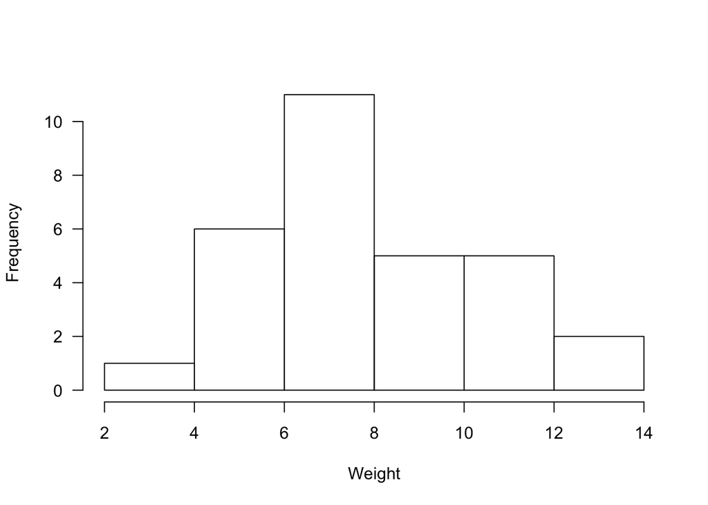

```r
hist(cowfood$weight, las = 1, ylab = "Frequency", xlab = "Weight", main = "")
```

OR

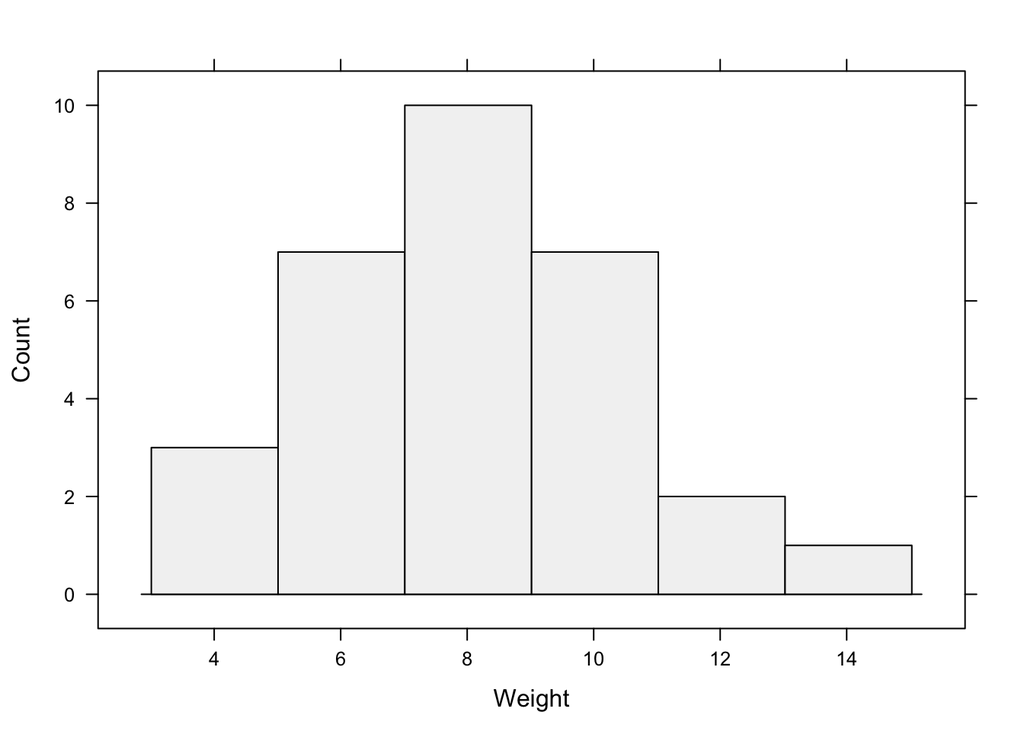

```r
histogram(~ weight, data = cowfood, type = "count", xlab = "Weight")
```

**Test knitting your file now** (did you remember to download the Word style document into your working directory?)

### Question 2 (1 marks)

Using the `cowfood` data frame, calculate the mean and standard deviation for the `weight` variable, grouped by feed type (**1 mark**).

```r
favstats(weight ~ feed, data = cowfood)
```

| feed | min | Q1 | median | Q3 | max | mean | sd | n | missing |
| --- | --- | --- | --- | --- | --- | --- | --- | --- | --- |
| Corn | 7.49 | 9.4250 | 10.285 | 11.5875 | 13.66 | 10.358 | 1.907772 | 10 | 0 |
| Flax | 5.51 | 7.0375 | 7.975 | 8.2625 | 10.92 | 7.838 | 1.651456 | 10 | 0 |
| Grass | 3.64 | 4.5625 | 6.165 | 6.9675 | 7.82 | 5.934 | 1.517851 | 10 | 0 |

OR

```r
mean(weight ~ feed, data = cowfood)
```

```
##   Corn   Flax  Grass
## 10.358  7.838  5.934
```

```r
sd(weight ~ feed, data = cowfood)
```

```
##     Corn     Flax    Grass
## 1.907772 1.651456 1.517851
```

**Save your work!!**

### Question 3 (2 marks)

1. Create a new dataframe (call it “corncow”) that includes only the “Corn” fed calves in the `cowfood` dataset (**1 mark**)

Insert your code in chunk below:

```r
corncow <- subset(cowfood, feed == "Corn")
```

OR

Load the `dplyr` package and use:

```r
corncow <- filter(cowfood, feed == "Corn")
```

2. Produce a normal quantile plot of the raw weight measurements from your new “corncow” dataframe created above (**1 mark**).

Insert your code in chunk below:

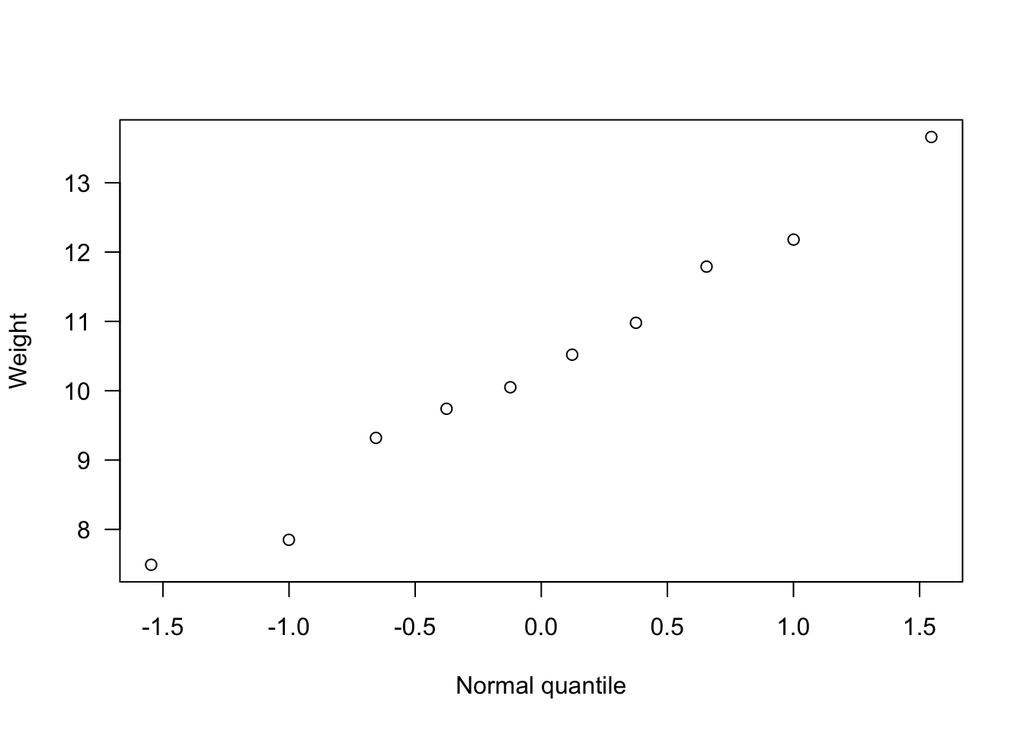

```r
qqnorm(corncow$weight, main = "",
       las = 1,
       xlab = "Normal quantile",
       ylab = "Weight")
```

### Question 4 (3 marks)

Using the `beaksize` dataset:

1. Conduct an appropriate statistical test to test whether the mean beak length differs among the two bird species (assume all assumptions are met) (**1 mark**)

Do the statistical test here:

Because we assume equal variances, we be sure to set the argument “var.equal” to TRUE (which is not the default in R):

```r
t.test(length ~ species, beaksize, var.equal = T)
```

```
##
##  Two Sample t-test
##
## data:  length by species
## t = -4.3278, df = 44, p-value = 8.545e-05
## alternative hypothesis: true difference in means is not equal to 0
## 95 percent confidence interval:
##  -1.0979824 -0.4002785
## sample estimates:
##  mean in group Black mean in group Boreal
##             6.087826             6.836957
```

2. Provide a concluding statement with all appropriate information included (**2 marks**)

Type your concluding statement in this area:

> Mean beak length differed significantly among the two bird species (2-sample t-test; t = -4.33, df = 44, P < 0.001; 95% confidence limits for the difference = -1.098, -0.400).

OR

> Mean beak length was significantly longer in the Boreal species compared to the Black species (2-sample t-test; t = 4.33, df = 44, P < 0.001; 95% confidence limits for the difference = 0.400, 1.098).

### Question 5 (1 mark)

Using the `esoph` dataset and its variable `agegp` (which stands for “age group”), tabulate the frequency of observations (subjects) within each age group (**1 mark**).

```r
table(esoph$agegp)
```

```
##
## 25-34 35-44 45-54 55-64 65-74   75+
##    15    15    16    16    15    11
```

### Question 6 (1 mark)

Using the `esoph` dataset and its variable `alcgp` (which stands for “alcohol consumption”) , provide a 95% confidence interval for the proportion of subjects who consumed 40-79g/day (**1 mark**).

```r
table(esoph$alcgp)
```

```
##
## 0-39g/day     40-79    80-119      120+
##        23        23        21        21
```

```r
num.success <- 23
total.sampsize <- sum(table(esoph$alcgp))
binom.confint(x = num.success, n = total.sampsize, conf.level = 0.95, methods = "ac")
```

|  | method | x | n | mean | lower | upper |
| --- | --- | --- | --- | --- | --- | --- |
| 1 | agresti-coull | 23 | 88 | 0.2613636 | 0.180406 | 0.3622842 |

### Question 7 (4 marks)

Using the `cowfood` dataset, is there an effect of food type on mean calf weight?

- Assume that all assumptions for the test are met (but see next point)
- Test whether the variance of the weight measurements is equal among food types (**1 mark**)
- Provide an appropriate graph showing mass in relation to treatment, with standard error bars (**1 mark**)
- Conduct an appropriate statistical test to answer the question; only show the R code (**1 mark**).
- No need to provide a “post-hoc” test
- Provide a concluding statement that includes all the appropriate information, including R<sup>2</sup> (but no need to refer to a Table) (**1 mark**)

My R chunk for test of equal variance:

```r
leveneTest(weight ~ feed, cowfood)
```

|  | Df | F value | Pr(>F) |
| --- | --- | --- | --- |
| group | 2 | 0.2384894 | 0.789459 |
|  | 27 | NA | NA |

My R chunk for the figure (no figure caption necessary):

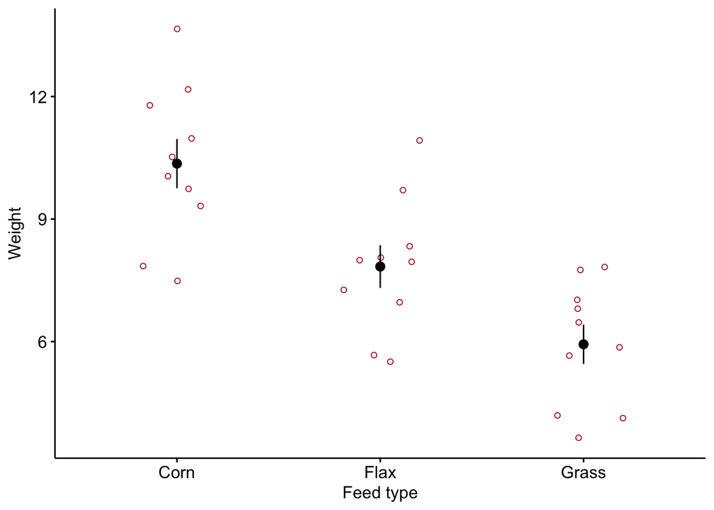

```r
ggstripchart(cowfood,
          x = "feed",
          y = "weight",
          xlab = "Feed type",
          ylab = "Weight",
          shape = 1, # hollow circles for points
          color = "firebrick", # color for points
          add = "mean_se", # adds +/- one standard error
          add.params = list(color = "black")) # colour for error bars
```

My R chunk for statistical test, and any additional commands required:

```r
cow.lm <- lm(weight ~ feed, data = cowfood)
cow.aov <- anova(cow.lm)
cow.aov
```

|  | Df | Sum Sq | Mean Sq | F value | Pr(>F) |
| --- | --- | --- | --- | --- | --- |
| feed | 2 | 98.49131 | 49.245653 | 17.0385 | 1.637051e-05 |
| Residuals | 27 | 78.03696 | 2.890258 | NA | NA |

And now get the coefficient of determination (R^2):

```r
summary(cow.lm)$r.squared
```

```
## [1] 0.557935
```

Concluding statement:

Average calf weight differed significantly among food types (ANOVA; F = 17.04; df = 2, 27; R-square = 0.56; P < 0.001).

### Question 8 (4 marks)

Using the `wings` dataset, test whether there is a significant linear association between left and right wing length.

- Assume that all assumptions for the test are met (see next point)
- Conduct a formal statistical test of normality for **left wing lengths** (**1 mark**)
- Provide an appropriate graph to visualize the association (**1 mark**)
- Conduct an appropriate test to test the strength of the linear association (**1 mark**)
- Provide a concluding statement that includes all the appropriate information (**1 mark**)

My R chunk for the test of normality:

```r
shapiro.test(wings$leftlength)
```

```
##
##  Shapiro-Wilk normality test
##
## data:  wings$leftlength
## W = 0.96468, p-value = 0.4919
```

My R chunk for the figure with figure caption:

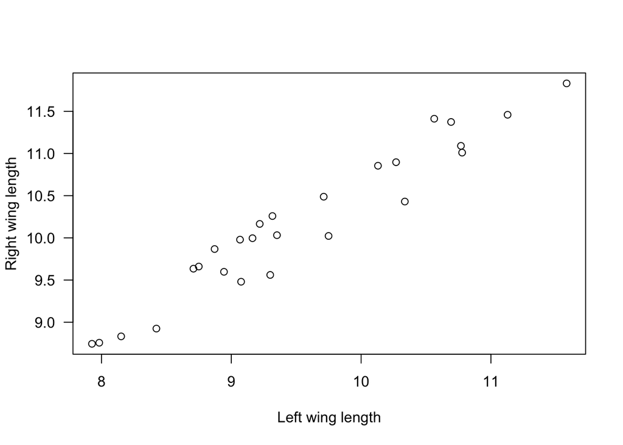

Scatterplot of the association between left and right wing lengths (N = 26)

```r
plot(rightlength ~ leftlength, wings, las = 1, pch = 1, xlab = "Left wing length", ylab = "Right wing length")
```

My R chunk for statistical test:

```r
cor.test(wings$rightlength, wings$leftlength)
```

```
##
##  Pearson's product-moment correlation
##
## data:  x and y
## t = 18.049, df = 24, p-value = 1.813e-15
## alternative hypothesis: true correlation is not equal to 0
## 95 percent confidence interval:
##  0.9226389 0.9844293
## sample estimates:
##       cor
## 0.9650835
```

Concluding statement:

There is a significant correlation between left and right wing lengths (Pearson correlation; r = 0.965; df = 24; P < 0.001; 95% confidence interval for the correlation coefficient: 0.923 - 0.984)

### Submit your exam

Knit your document to Word, save the word file as a PDF, double-check that the PDF looks the way you want it to, then submit it to Connect **before** the 1 hour 20 minute mark.

**DO NOT** share any of this material with your classmates. **Cheating will result in a zero for all parties involved**.